# Reproduce analyses of Hooper et al. 2012

Alejandra, Aurelie, Marco et al.

# Introduction

This is an attempt to reproduce the anaylses presented in the paper *A global synthesis reveals biodiversity loss as a major driver of ecosystem change by Hooper et al. 2012 ([http://jarrettbyrnes.info/pdfs/Hooper_et_al_2012_Nature.pdf]).

- From the article summary: There is evidence that extinctions are altering key processes important to the productivity and sustainability of Earth’s eco- systems. Further species loss will accelerate change in ecosystem processes, but it is unclear how these effects compare to the direct effects of other forms of environmental change that are both driving diversity loss and altering ecosystem function. The authors used a suite of meta-analyses of published data to show that the effects of species loss on productivity and decomposition — two processes important in all ecosystems — are of comparable magnitude to the effects of many other global environmental changes. NUMBER OF SPECIES LOSS: In experiments, intermediate levels of species loss (21–40%) reduced plant production by 5–10%, comparable to previously documented effects of ultraviolet radiation and climate warming. Higher levels of extinction (41–60%) had effects rivalling those of ozone, acidification, elevated CO2 and nutrient pollution. At intermediate levels, species loss generally had equal or greater effects on de- composition than did elevated CO2 and nitrogen addition. IDENTITY OF SPECIES LOSS: The identity of species lost also had a large effect on changes in pro- ductivity and decomposition, generating a wide range of plausible outcomes for extinction.
- From authors

Many experiments have shown that species loss can alter key processes important to the productivity and sustainability of Earth’s ecosystems. However, it is unclear how these effects compare to the direct effects of other forms of environmental change that are both driving diversity loss and altering ecosystem function. We used a suite of meta-analyses of published data to show that the impacts of species loss on productivity and decomposition - two processes important in all ecosystems are of comparable magnitude to impacts of many other global environmental changes. These analyses were published by Hooper et al. in Nature in 2012 (online release date: May 2, 2012, DOI: 10.1038/nature11118). This archive contains the data and statistical details for the two sets of analyses found in that paper. In the first, we performed a broad meta-analysis to compare effects of changing species richness on primary production and decomposition, as derived from a database on biodiversity-ecosystem functioning (BEF) experiments, with effects of major environmental changes as derived from already published meta-analyses. For both biodiversity and environmental effects, we use log response ratios for effect sizes. This analysis allows a broad comparison across many experiments, but in so doing, compares effects of species richness with those of other environmental changes in different experiments performed by different researchers in different ecosystems. Therefore, we undertook a second analysis focusing on the relative magnitude of effects of species richness and environmental change in experiments that factorially manipulated both. For this, we used a much smaller subset of experiments from the BEF database, and only analyzed primary production as the response variable. Here we include the data and any processing steps, including R-code and description, that were used in our analyses. In experiments, intermediate levels of species loss (21-40%) reduced plant production by 5-10%, comparable to previously documented impacts of ultra-violet radiation and climate warming. Higher levels of extinction (41-60%) had impacts rivaling those of ozone, acidification, elevated CO2, and nutrient pollution. At intermediate levels, species loss generally had equal or greater impacts on decomposition than did elevated CO2 and nitrogen addition. The identity of species lost also had a large impact on changes in productivity and decomposition, generating a wide range of plausible outcomes for extinction. Despite need for more studies on interactive effects of diversity loss and environmental changes, our analyses clearly show that the ecosystem consequences of local species loss are as quantitatively significant as direct effects of several global change stressors that have mobilized major international concern and remediation efforts.

# Data Files content

For figure 1: Changes in primary production as a function of per cent local species lost. In this figure, authors show the effects of species loss on primary production.

(PowerCoeffs_Prod_min): 308 included experiments(Y) - they say 379 - , with information on Maximum and minimum level of richness, Maximum likelihood estimates a and b from a linearized version of the power function ln(Yi/Y1) = a + b*ln(S) where Yi is the value of Y at richness S, and Y1 is the mean monoculture value of Y at S = 1.

(Prod_OtherFactors): Information on global change factors, log response ratio (EFFECT SIZE??), lower and upper 95% confidence interval value, LRR for diversity (?), level of diversity loss where diversity LRR is approximately equal to the LRR for each global change factor.

For figure 2: Changes in decomposition as a function of percent of local species lost. In this figure authors show the effect of a) detrital consumer diversity and b) plant litter diversity in decomposition

- in these files: different dataset, same information

# Clear R and load data

```r
#clear R
rm(list=ls())
library(plyr)
library(RCurl)
# Power coefficients of the effect of biodiversity loss on productivity
powInfo <- read.csv(text=getURL("https://raw.githubusercontent.com/opetchey/RREEBES/master/Hooper_etal_2012/Data_Fig_1_and_2/PowerCoeffs_Prod_min.csv"), check.names=FALSE)
head(powInfo)
```

```
##   Entry Study Expt Smax   powa   powb Smin FinalT
## 1    26     5   12   24 2.6656 1.1798   19      Y
## 2    29     5   13   24 0.3852 1.9978   19      Y
## 3    44     8   17    7     NA     NA    1      Y
## 4    45     8   18    9 0.9107 0.1082    1      Y
## 5    46     8   19    6 0.5906 0.0596    1      Y
## 6    47     8   20    6 7.1836 0.0077    1      Y
```

```r
# Power coefficients of the effect of biodiversity loss (consumers) on decomposition
powInfoCons <- read.csv(text=getURL("https://raw.githubusercontent.com/opetchey/RREEBES/Hooper_et_al_2012/Hooper_etal_2012/data/PowerCoeffs_ConsumDivDecomp_min.csv"), check.names=FALSE)
head(powInfoCons)
```

```
##   Entry Study Expt Smax    powa   powb Smin FinalT
## 1     7     3    3    5 -5.0077 0.0138    1      Y
## 2     8     3    4    5 -4.0915 0.0737    1      Y
## 3     9     3    5    5 -3.4052 0.1901    1      Y
## 4    10     3    6    5 -3.4291 0.3516    1      Y
## 5    11     3    7    5 -2.7379 0.1796    1      Y
## 6    12     3    8    5 -2.7843 0.1082    1      Y
```

```r
# Power coefficients of the effect of biodiversity loss (litter) on decomposition
powInfoLitt <- read.csv(text=getURL("https://raw.githubusercontent.com/opetchey/RREEBES/master/Hooper_etal_2012/Data_Fig_1_and_2/PowerCoeffs_LitterDivDecomp_min.csv"), check.names=FALSE)
head(powInfoLitt)
```

```
##   Entry Study Expt Smax    powa    powb Smin FinalT
## 1     3     2    2    6 -0.4662  0.1044    1      Y
## 2     5     2    2    6  0.7302 -0.0093    1      Y
## 3    75    15   28    5  6.9596  0.1361    1      Y
## 4   199    35   73    3      NA      NA    1      Y
## 5   200    35   74    3      NA      NA    1      Y
## 6   202    36   75    6 -1.7748 -0.2992    1      Y
```

```r
# Select the studies that were included in the meta-analysis
powInfo<-subset(powInfo,powInfo$FinalT=="Y")
powInfoCons<-subset(powInfoCons,powInfoCons$FinalT=="Y")
powInfoLitt<-subset(powInfoLitt,powInfoLitt$FinalT=="Y")

# Effects of environmnetal factors affecting productivity
prod.other <- read.csv(text=getURL("https://raw.githubusercontent.com/opetchey/RREEBES/master/Hooper_etal_2012/Data_Fig_1_and_2/Prod_OtherFactors.csv"), check.names=FALSE)
prod.other
```

```
##                     group         est       lower       upper diffpt xval
## 1                 Drought -0.61618614 -0.89159812 -0.34249031      1  105
## 2           Acidification -0.18632958 -0.34249031 -0.02020271      1  109
## 3         Elevated Ozone  -0.14885400 -0.16091880 -0.13678920      1  113
## 4                      UV -0.08228255 -0.10716390 -0.05740122      1  117
## 5                Warming   0.11600368  0.07774496  0.15426239      0  121
## 6          Elevated CO2    0.21736250  0.20732110  0.22740390      0  125
## 7                 Added P  0.23873300  0.17513770  0.30232830      0  129
## 8                Added N   0.30975570  0.19179970  0.42771180      0  133
## 9            Nutrients Ca  0.35065687 -0.10536052  0.81977983      0  137
## 10        Plant Invasion   0.51361530  0.44654890  0.58068170      0  141
## 11 Added N & Elevated CO2  0.69410740  0.62221130  0.76600350      0  145
## 12           Added N & P   0.96390320  0.89404410  1.03376200      0  149
```

```r
# Effects of environmnetal factors affecting decomposition
decomp.other <- read.csv(text=getURL("https://raw.githubusercontent.com/opetchey/RREEBES/Hooper_et_al_2012/Hooper_etal_2012/data/Decomp_OtherFactors.csv"), check.names=FALSE)
decomp.other
```

```
##                 group    est  lower  upper diffpt xval
## 1  Elevated CO  (101) -0.020 -0.041  0.010      1  128
## 2       Added N (520) -0.023 -0.046  0.000      1  118
## 3  Eutrophication (6)  0.250 -0.180  0.660      0  138
## 4 Plant Invasion (62)  0.729  0.677  0.782      0  148
## 5       Acidifcation  -0.830     NA -0.520      1  108
```

# GENERATE CURVE DATA FOR ALL THREE PANELS

```r
# PRODUCTIVITY METAMETA: generate curve data at step = 0.05 (5%) ending at smallest proportion remaining
#   value in the data (0.03)
extCurve<-with(powInfo, {
  ddply(data.frame(Remaining=seq(0.03,.99,0.05)), .(Remaining),

        function(adf){
          rem<-adf$Remaining[1]
          YMax<-exp(powa+powb*log(Smax))
          Y_rem<-exp(powa+powb*log(rem*Smax))

          lrr<-log(Y_rem/YMax)
          rr<-(Y_rem/YMax)

          #Exclude exp after reached its min % rem spp; exclude if %rem < exp.min%rem
          excludeIdx<-which(rem<Smin/Smax)
          lrr[excludeIdx] <- NA
          rr[excludeIdx] <- NA

          return( c(MeanLRR = mean(lrr, na.rm=T), sdLRR=sd(lrr, na.rm=T),
                    ext=1-adf$Remaining,nobs=length(na.exclude(lrr)),MeanRR=mean(rr,na.rm=T)))

        })

})
#get rid of weird duplicates
extCurve<-extCurve[which(!duplicated(extCurve[,1])),]
```

```r
# CONSUMER DIVERSITY DECOMPOSITION METAMETA: generate curve at step 0.05
#   0.014 (0.2)is min (smin/smax)
extCurveCons<-with(powInfoCons, {
  ddply(data.frame(Remaining=seq(0.02,.99,0.05)), .(Remaining),

        function(adf){
          rem<-adf$Remaining[1]
          YMax<-exp(powa+powb*log(Smax))
          Y_rem<-exp(powa+powb*log(rem*Smax))

          lrr<-log(Y_rem/YMax)
          rr<-(Y_rem/YMax)

          #Exclude exp after reached its min % rem spp; exclude if %rem < exp.min%rem
          excludeIdx<-which(rem<Smin/Smax)
          lrr[excludeIdx] <- NA
          rr[excludeIdx] <- NA

          return( c(MeanLRR = mean(lrr, na.rm=T), sdLRR=sd(lrr, na.rm=T),
                    ext=1-adf$Remaining,nobs=length(na.exclude(lrr)),MeanRR=mean(rr,na.rm=T)))

        })
})
#get rid of weird duplicates
extCurveCons<-extCurveCons[which(!duplicated(extCurveCons[,1])),]
```

```r
# PRODUCER DIVERSITY DECOMPOSITION METAMETA: generate curve at step 0.05
#   0.04 is min (smin/smax)
extCurveLitt<-with(powInfoLitt, {
  ddply(data.frame(Remaining=seq(0.04,.99,0.05)), .(Remaining),

        function(adf){
          #browser()
          rem<-adf$Remaining[1]
          YMax<-exp(powa+powb*log(Smax))
          Y_rem<-exp(powa+powb*log(rem*Smax))

          lrr<-log(Y_rem/YMax)
          rr<-(Y_rem/YMax)

          #Exclude exp after reached its min % rem spp; exclude if %rem < exp.min%rem
          excludeIdx<-which(rem<Smin/Smax)
          lrr[excludeIdx] <- NA
          rr[excludeIdx] <- NA

          return( c(MeanLRR = mean(lrr, na.rm=T), sdLRR=sd(lrr, na.rm=T),
                    ext=1-adf$Remaining,nobs=length(na.exclude(lrr)),MeanRR=mean(rr,na.rm=T)))

        })
})
#get rid of weird duplicates
extCurveLitt<-extCurveLitt[which(!duplicated(extCurveLitt[,1])),]
```

They homogeneise the standard deviation to confidence interval for the consumer and litter diversity decomposition

```r
#Convert SD to CI
#PRODUCTIVITY
err<-extCurve
err$CItemp=numeric(nrow(extCurve))
err$CI.lo=numeric(nrow(extCurve))
err$CI.up=numeric(nrow(extCurve))
i=which(extCurve$nobs>0)
err<-within(err, {
  CItemp[i] <- qt(0.025, nobs[i]-1, lower.tail=F)*sdLRR[i]/sqrt(nobs[i])
  CI.lo[i]<-MeanLRR[i]-CItemp[i]
  CI.up[i]<-MeanLRR[i]+CItemp[i]
})
#CONSUMER DIV-DECOMP
errCons<-extCurveCons
errCons$CItemp=numeric(nrow(extCurveCons))
errCons$CI.lo=numeric(nrow(extCurveCons))
errCons$CI.up=numeric(nrow(extCurveCons))
i=which(extCurveCons$nobs>0)
errCons<-within(errCons, {
  CItemp[i] <- qt(0.025, nobs[i]-1, lower.tail=F)*sdLRR[i]/sqrt(nobs[i])
  CI.lo[i]<-MeanLRR[i]-CItemp[i]
  CI.up[i]<-MeanLRR[i]+CItemp[i]
})
#LITTER DIV-DECOMP
errLitt<-extCurveLitt
errLitt$CItemp=numeric(nrow(extCurveLitt))
errLitt$CI.lo=numeric(nrow(extCurveLitt))
errLitt$CI.up=numeric(nrow(extCurveLitt))
i=which(extCurveLitt$nobs>0)
errLitt<-within(errLitt, {
  CItemp[i] <- qt(0.025, nobs[i]-1, lower.tail=F)*sdLRR[i]/sqrt(nobs[i])
  CI.lo[i]<-MeanLRR[i]-CItemp[i]
  CI.up[i]<-MeanLRR[i]+CItemp[i]
})
#subset to get rid of MeanLRR=NA values
err<-na.exclude(err)
errCons<-na.exclude(errCons)
errLitt<-na.exclude(errLitt)

#Convert to percentages instead of proportions
#PRODUCTIVITY
err$percent<-err$ext*100
#CONSUMER & LITTER DIV-DECOMP
errCons$percent<-errCons$ext*100
errLitt$percent<-errLitt$ext*100

#output curve data (if desired)
#   write.table(err,"clipboard-768",sep="\t",row.names=FALSE,col.names=FALSE)
#   write.table(errCons,"clipboard-768",sep="\t",row.names=FALSE,col.names=FALSE)
#   write.table(errLitt,"clipboard-768",sep="\t",row.names=FALSE,col.names=FALSE)
```

# Make Fig 1: productivity

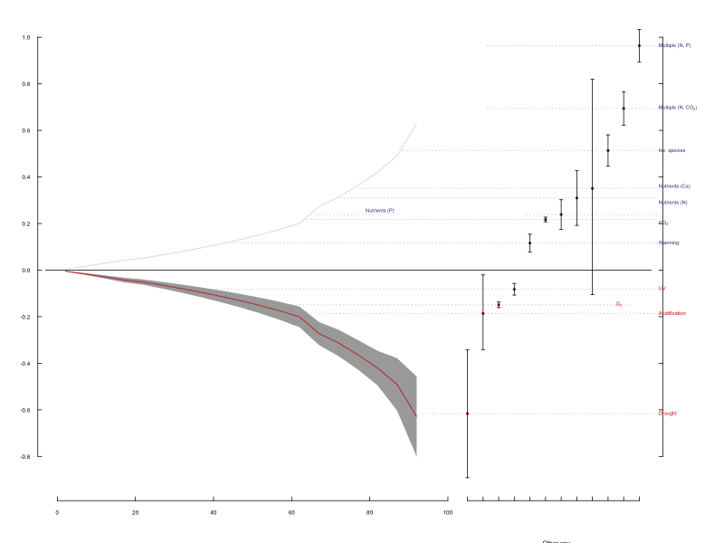

```r
#As a png
png("Fig1.png", width=800, height=600, pointsize=7)

par(omi=c(0,0,0,0)) #outer margin area in inches (oma = in number of lines, outer margin area)

#Set up graphical region to expect one plot
par(mfrow=c(1,1),xpd=NA)  #xpd=NA allows text and graphics outside of figure margins

#Draw figure
par(mai=c(.7, .52, .3, .88)) #bottom, left, top and right
cols <- c("MeanLRR")
matplot(err$percent, err[, cols], type="n", lwd=2,
        xlim=c(0,150), xaxt="n",
        ylim=c(-.9,1), yaxt="n",
        xlab="",cex.axis=0.85,bty="n",
        ylab="",tcl=0.5,cex.axis=0.9)
axis(2,pos=-5,tcl=0.5,cex.axis=.9,at=c(1.0,.8,.6,.4,.2,0,-.2,-.4,-.6,-.8),las=1)
#right axis
axis(4,ylim=c(-1,1),pos=155,tcl=0.5,at=c(1.0,.8,.6,.4,.2,0,-.2,-.4,-.6,-.8),lab=F)
#2 x axes
axis(1,xlim=c(0,150),pos=-0.99,tcl=0.5,at=c(0,20,40,60,80,100),cex.axis=.9)
axis(1,xlim=c(105,148),pos=-0.99,tcl=0.5,at=c(105,109,113,117,121,125,129,133,137,141,145,149),
     cex.axis=.9,lab=F)
text(x=-40,y=0,
     "Change in productivity caused by species loss",
     srt=90,cex=1)
text(x=-32,y=0.015,
     expression(paste("(log response ratio, ln[",Y[S],"/",Y[Smax],"])")),
     srt=90,cex=1)
text(x=211,y=0,
     "Change in productivity caused by environmental change",
     srt=90,cex=1)
text(x=219,y=0.03,
     expression(paste("(log response ratio,ln[",Y[expt],"/",Y[control],"])")),
     srt=90,cex=1)
text(x=50,y=-1.3,"Percent of species lost",cex=1)
text(x=128,y=-1.17,"Other env.",cex=1)
text(x=128,y=-1.3,"changes (by size)",cex=1)
#Shaded CI
i.for<-order(err$percent)
i.back<-order(err$percent,decreasing=TRUE)
x.polygon<-c(err$percent[i.for], err$percent[i.back])
y.polygon<-c(err$CI.lo[i.for],err$CI.up[i.back])
polygon(x.polygon,y.polygon,col="#A9A9A9",border=NA)
#add curve
matplot(err$percent, err[, cols], type="l", lwd=1, bty="l",
        col=colors()[(555)], add=TRUE)
#positive curve
matplot(err$percent, err$MeanLRR*-1, type="l", lwd=.25, bty="l", lty=1,
        col=colors()[(555)], add=TRUE)
#add zero line
segments(x0=-3,y0=0,x1=152,y1=0,col="black")
#Negative factor effect lines & text
segments(x0=55.5,y0=-0.148854,x1=147,y1=-0.148854,col=colors()[(332)],lty=3) #Elevated Ozone
text(x=142,y=-0.148854,expression(paste(O[3])),col=colors()[(555)],pos=4,cex=.8)
segments(x0=92.5,y0=-0.616186139,x1=154,y1=-0.616186139,col=colors()[(332)],lty=3) #Drought
text(x=153,y=-0.616186139,"Drought",col=colors()[(555)],pos=4,cex=.8)
segments(x0=38,y0=-0.082,x1=154,y1=-0.082,col=colors()[(332)],lty=3) #UV
text(x=153,y=-0.08,"UV",col=colors()[(555)],pos=4,cex=.8)
segments(x0=63,y0=-0.186,x1=154,y1=-0.186,col=colors()[(332)],lty=3) #acidification
text(x=153,y=-0.186,"Acidification",col=colors()[(555)],pos=4,cex=.8)
#plot negative effects and 95% CIs
neg<-subset(prod.other,prod.other$diffpt==1)
matplot(neg$xval, neg$est,pch = 16, cex=1, col=colors()[(555)], add=TRUE)
#add CIs
arrows(neg$xval,neg$est,neg$xval,neg$upper,length=0.03,angle=90)
arrows(neg$xval,neg$est,neg$xval,neg$lower,length=0.03,angle=90)
#Positive factor effect lines & text
segments(x0=45,y0=0.116003676,x1=154,y1=0.116003676,col=colors()[(332)],lty=3) #Warming
text(x=153,y=0.116003676,"Warming",col=colors()[(566)],pos=4,cex=.8)
segments(x0=64,y0=0.2173625,x1=154,y1=0.2173625,col=colors()[(332)],lty=3) #+CO2
text(x=153,y=0.20,expression(paste(CO[2])),col=colors()[(566)],pos=4,cex=.8)
segments(x0=66,y0=0.238733,x1=83,y1=0.238733,col=colors()[(332)],lty=3) #+P
segments(x0=120,y0=0.238733,x1=155,y1=0.238733,col=colors()[(332)],lty=3) #+P
text(x=78,y=0.255,"Nutrients (P)",col=colors()[(566)],pos=4,cex=.8)
segments(x0=72.5,y0=0.3097557,x1=154,y1=0.3097557,col=colors()[(332)],lty=3) #+N
text(x=153,y=0.29,"Nutrients (N)",col=colors()[(566)],pos=4,cex=.8)
segments(x0=110,y0=0.6941074,x1=154,y1=0.6941074,col=colors()[(332)],lty=3) #+N, +CO2
text(x=153,y=0.6941074,expression(paste("Multiple (N, ",CO[2],")")),col=colors()[(566)],pos=4,cex=.8)
segments(x0=110,y0=0.9639032,x1=154,y1=0.9639032,col=colors()[(332)],lty=3) #+N, +P
text(x=153,y=0.9639032,"Multiple (N, P)",col=colors()[(566)],pos=4,cex=.8)
segments(x0=88.5,y0=0.5136153,x1=155,y1=0.5136153,col=colors()[(332)],lty=3) #Inv spp
text(x=153,y=0.5136153,"Inv. species",col=colors()[(566)],pos=4,cex=.8)
segments(x0=77,y0=0.351,x1=154,y1=0.351,col=colors()[(332)],lty=3) #Ca
text(x=153,y=0.36,"Nutrients (Ca)",col=colors()[(566)],pos=4,cex=.8)
#plot positive effects and 95% CIs
pos<-subset(prod.other,prod.other$diffpt==0)
matplot(pos$xval, pos$est,pch = 16, cex=1, col= colors()[(566)], add=TRUE)
#add CIs
arrows(pos$xval,pos$est,pos$xval,pos$upper,length=0.03,angle=90)
arrows(pos$xval,pos$est,pos$xval,pos$lower,length=0.03,angle=90)

# close PNG device
dev.off()
```

# Make Fig 2: decomposition

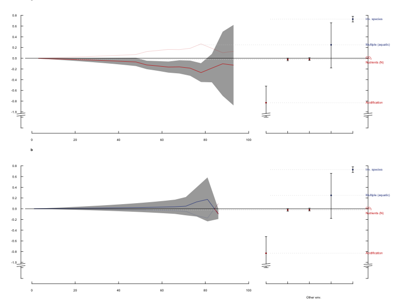

```r
# as a pdf file

png("Fig2.png",
    width=800, height=600, pointsize=7)
#89mm = 3.50393701; one column

par(omi=c(0,0,0,0)) #outer margin area in inches (oma = in number of lines, outer margin area)

#Set up graphical region to expect two stacked plots
par(mfrow=c(2,1),xpd=NA)  #xpd=NA allows text and graphics outside of figure margins

###################
#make CONSUMER plot - Part A
par(mai=c(.5, .52, .3, .88)) #bottom, left, top and right
cols <- c("MeanLRR")
matplot(errCons$percent, errCons[, cols], type="n", xlim=c(0,150),lwd=2,
        ylim=c(-1.3,0.8), yaxt="n",xaxt="n",
        xlab="",cex.axis=0.85,bty="n",
        ylab="",tcl=0.5)
#left axis
axis(2,ylim=c(0,1.2),pos=-5,tcl=0.5,cex.axis=.9,at=c(.8,.6,.4,.2,0,-.2,-.4,-.6,-.8,-1),las=1)
axis(2,ylim=c(0,1.2),pos=-5,tcl=0.5,cex.axis=.9,lab=F,at=c(-1.1,-1.3))
#fake axis break
segments(x0=-5,y0=-1,x1=-5,y1=-1.03,col="black")
segments(x0=-7,y0=-1.04,x1=-3,y1=-1.02,col="black")
segments(x0=-5,y0=-1.07,x1=-5,y1=-1.1,col="black")
segments(x0=-7,y0=-1.08,x1=-3,y1=-1.06,col="black")
#right axis
axis(4,ylim=c(0,1.2),pos=155,tcl=0.5,lab=F,at=c(.8,.6,.4,.2,0,-.2,-.4,-.6,-.8,-1),las=1)
axis(4,ylim=c(0,1.2),pos=155,tcl=0.5,cex.axis=.9,lab=F,at=c(-1.1,-1.3))
#fake axis break
segments(x0=155,y0=-1,x1=155,y1=-1.03,col="black")
segments(x0=153,y0=-1.04,x1=157,y1=-1.02,col="black")
segments(x0=155,y0=-1.07,x1=155,y1=-1.1,col="black")
segments(x0=153,y0=-1.08,x1=157,y1=-1.06,col="black")
text(x=-21,y=-1.3,"-1.8",cex=0.9)
#x axis
axis(1,xlim=c(0,150),pos=-1.4,tcl=0.5,at=c(0,20,40,60,80,100),cex.axis=.9)
axis(1,xlim=c(105,148),pos=-1.4,tcl=0.5,at=c(108,118,128,138,148),
     cex.axis=.9,lab=F)
#Shaded CI
i.for<-order(errCons$percent)
i.back<-order(errCons$percent,decreasing=TRUE)
x.polygon<-c(errCons$percent[i.for], errCons$percent[i.back])
y.polygon<-c(errCons$CI.lo[i.for],errCons$CI.up[i.back])
polygon(x.polygon,y.polygon,col="#A9A9A9",border=NA)
#add curves
matplot(errCons$percent, errCons[, cols], type="l", lwd=1, bty="l",
        col=colors()[(555)], add=TRUE)
#abs value curve
matplot(errCons$percent, errCons$MeanLRR*-1, type="l", lwd=.25, bty="l",
        col=colors()[(555)], add=TRUE)
#add zero line
segments(x0=-3,y0=0,x1=155,y1=0,col="black")
#Negative factor effect lines & text
segments(x0=21,y0=-0.020202707,x1=154,y1=-0.020202707,col=colors()[(343)],lty=3) #+CO2
text(x=153,y=-.001,expression(paste(CO[2])),col=colors()[(555)],pos=4,cex=.9)
segments(x0=22,y0=-0.02325821,x1=154,y1=-0.02325821,col=colors()[(343)],lty=3) #+N
text(x=153,y=-0.08,"Nutrients (N)",col=colors()[(555)],pos=4,cex=.9)
segments(x0=110,y0=-0.830,x1=154,y1=-0.830,col=colors()[(343)],lty=3) #Acidification
text(x=153,y=-0.830,"Acidification",col=colors()[(555)],pos=4,cex=.9)
#plot negative effects and 95% CIs
neg<-subset(decomp.other,decomp.other$diffpt==1)
matplot(neg$xval, neg$est,pch = 16, cex=1, col=colors()[(555)], add=TRUE)#all but acidification
#add CIs acidification lower & upper = -1.6 -0.52
arrows(neg$xval,neg$est,neg$xval,neg$upper,length=0.03,angle=90)
arrows(neg$xval,neg$est,neg$xval,neg$lower,length=0.03,angle=90)
#lower acidification CI by hand (fake break)
segments(x0=108,y0=-.83,x1=108,y1=-1.03,col="black")
segments(x0=110,y0=-1.02,x1=106,y1=-1.04,col="black")
segments(x0=108,y0=-1.07,x1=108,y1=-1.1,col="black")
segments(x0=110,y0=-1.06,x1=106,y1=-1.08,col="black")
segments(x0=107,y0=-1.1,x1=109,y1=-1.1,col="black")
#Positive factor effect lines & text
segments(x0=77,y0=0.25,x1=154,y1=0.25,col=colors()[(343)],lty=3) #Eutrophication
text(x=153,y=0.25,"Multiple (aquatic)",col=colors()[(566)],pos=4,cex=.9)
segments(x0=110,y0=0.7294916,x1=154,y1=0.7294916,col=colors()[(343)],lty=3) #invasion
text(x=153,y=0.7294916,"Inv. species",col=colors()[(566)],pos=4,cex=.9)
#plot positive effects and 95% CIs
pos<-subset(decomp.other,decomp.other$diffpt==0)
matplot(pos$xval, pos$est,pch = 16, cex=1, col= colors()[(566)], add=TRUE)
#add CIs
arrows(pos$xval,pos$est,pos$xval,pos$upper,length=0.03,angle=90)
arrows(pos$xval,pos$est,pos$xval,pos$lower,length=0.03,angle=90)
#add additional text
thestring<-"a"
text(x=0,y=1.1,labels=bquote(bold(.(thestring))))
text(x=-40,y=-2,"Change in decomposition caused by species loss", srt=90)
text(x=-32,y=-2,expression(paste("(log response ratio, ln[",Y[S],"/",Y[Smax],"])"))
     ,srt=90)
text(x=211,y=-2,"Change in decomposition caused by environmental change",
     srt=90)
text(x=219,y=-2,expression(paste("(log response ratio, ln[",Y[expt],"/",Y[control],"])")),
     srt=90)

################
#make LITTER plot - Part B
par(mai=c(.5, .52, .3, .88)) #bottom, left, top and right
cols <- c("MeanLRR")
matplot(errLitt$percent, errLitt[, cols], type="n", xlim=c(0,150),lwd=2,
        ylim=c(-1.3,0.8), yaxt="n",xaxt="n",
        xlab="",cex.axis=0.9,bty="n",
        ylab="",tcl=0.5)
#left axis
axis(2,ylim=c(0,1.2),pos=-5,tcl=0.5,cex.axis=.9,at=c(.8,.6,.4,.2,0,-.2,-.4,-.6,-.8,-1),las=1)
axis(2,ylim=c(0,1.2),pos=-5,tcl=0.5,cex.axis=.9,lab=F,at=c(-1.1,-1.3))
#fake axis break
segments(x0=-5,y0=-1,x1=-5,y1=-1.03,col="black")
segments(x0=-7,y0=-1.04,x1=-3,y1=-1.02,col="black")
segments(x0=-5,y0=-1.07,x1=-5,y1=-1.1,col="black")
segments(x0=-7,y0=-1.08,x1=-3,y1=-1.06,col="black")
#right axis
axis(4,ylim=c(0,1.2),pos=155,tcl=0.5,lab=F,at=c(.8,.6,.4,.2,0,-.2,-.4,-.6,-.8,-1))
axis(4,ylim=c(0,1.2),pos=155,tcl=0.5,cex.axis=.9,lab=F,at=c(-1.1,-1.3))
#fake axis break
segments(x0=155,y0=-1,x1=155,y1=-1.03,col="black")
segments(x0=153,y0=-1.04,x1=157,y1=-1.03,col="black")
segments(x0=155,y0=-1.07,x1=155,y1=-1.1,col="black")
segments(x0=153,y0=-1.08,x1=157,y1=-1.06,col="black")
text(x=-21,y=-1.3,"-1.8",cex=0.9)
#x axis
axis(1,xlim=c(0,150),pos=-1.4,tcl=0.5,at=c(0,20,40,60,80,100),cex.axis=.9)
axis(1,xlim=c(105,148),pos=-1.4,tcl=0.5,at=c(108,118,128,138,148),
     cex.axis=.9,lab=F)
text(x=55,y=-1.8,"Percent of species lost",cex=.9)
text(x=130,y=-1.65,"Other env.",cex=.9)
text(x=130,y=-1.8,"changes (by size)",cex=.9)
#Shaded CI
i.for<-order(errLitt$percent)
i.back<-order(errLitt$percent,decreasing=TRUE)
x.polygon<-c(errLitt$percent[i.for], errLitt$percent[i.back])
y.polygon<-c(errLitt$CI.lo[i.for],errLitt$CI.up[i.back])
polygon(x.polygon,y.polygon,col="#A9A9A9",border=NA)
#add curves
matplot(errLitt$percent, errLitt[, cols], type="l", lwd=1, bty="l",
        col=colors()[(566)], add=TRUE)
#abs value curve
matplot(errLitt$percent, -1*errLitt$MeanLRR, type="l", lwd=.25, bty="l",
        col=colors()[(566)], add=TRUE)
#add red portions of lines
segments(x0=84.2127565,y0=0,x1=86,y1=-0.097003093,col=colors()[(555)],lwd=1)
segments(x0=84.2127565,y0=0,x1=86,y1=0.097003093,col=colors()[(555)],lwd=.25)
#add zero line
segments(x0=-3,y0=0,x1=155,y1=0,col="black") #zero line
#Negative factor effect lines & text
segments(x0=53,y0=-0.020202707,x1=154,y1=-0.020202707,col=colors()[(343)],lty=3) #+CO2
text(x=153,y=-.0009,expression(paste(CO[2])),col=colors()[(555)],pos=4,cex=.9)
segments(x0=56,y0=-0.02325821,x1=154,y1=-0.02325821,col=colors()[(343)],lty=3) #+N
text(x=153,y=-0.085,"Nutrients (N)",col=colors()[(555)],pos=4,cex=.9)
segments(x0=110,y0=-0.830,x1=154,y1=-0.830,col=colors()[(343)],lty=3) #Acidification
text(x=153,y=-0.830,"Acidification",col=colors()[(555)],pos=4,cex=.9)
#plot negative effects and 95% CIs
neg<-subset(decomp.other,decomp.other$diffpt==1)
matplot(neg$xval, neg$est,pch = 16, cex=1, col=colors()[(555)], add=TRUE)#all but acidification
#add CIs acidification lower & upper = -1.6 -0.52
arrows(neg$xval,neg$est,neg$xval,neg$upper,length=0.03,angle=90)
arrows(neg$xval,neg$est,neg$xval,neg$lower,length=0.03,angle=90)
#lower acidification CI by hand (fake break)
segments(x0=108,y0=-.83,x1=108,y1=-1.03,col="black")
segments(x0=110,y0=-1.02,x1=106,y1=-1.04,col="black")
segments(x0=108,y0=-1.07,x1=108,y1=-1.1,col="black")
segments(x0=110,y0=-1.06,x1=106,y1=-1.08,col="black")
segments(x0=107,y0=-1.1,x1=109,y1=-1.1,col="black")
#Positive factor effect lines & text
segments(x0=110,y0=0.25,x1=154,y1=0.25,col=colors()[(343)],lty=3) #Eutrophication
text(x=153,y=0.25,"Multiple (aquatic)",col=colors()[(566)],pos=4,cex=.9)
segments(x0=110,y0=0.7294916,x1=154,y1=0.7294916,col=colors()[(343)],lty=3) #invasion
text(x=153,y=0.7294916,"Inv. species",col=colors()[(566)],pos=4,cex=.9)
#plot positive effects and 95% CIs
pos<-subset(decomp.other,decomp.other$diffpt==0)
matplot(pos$xval, pos$est,pch = 16, cex=1, col= colors()[(566)], add=TRUE)
#add CIs
arrows(pos$xval,pos$est,pos$xval,pos$upper,length=0.03,angle=90)
arrows(pos$xval,pos$est,pos$xval,pos$lower,length=0.03,angle=90)
#add additional text
thestring<-"b"
text(x=0,y=1.1,labels=bquote(bold(.(thestring))))#"b",cex=1.1,font.main=3)

# close PDF device
dev.off()
```

# Table 1

Effects of species richness and environmental changes on primary productivity for the broad meta-analysis and factorial diversity crossed with environment experiments.

In this table, authors show the effect sizes (and confidence intervals) for a loss of primary producers diversity of 50% on the primary productivity. They also include for comparison the effect of the avergae monoculture and the best monoculture - they explain methods how they calculated the LRRs for this.

They also include for comparison, the effect of global change drivers, alone or combined.

Negative values mean a decline in productivity rates.

They did this analysis for a broad meta-analysis with 192 publicacions on a variety of ecosystems 9first part of the table). Then they complement this with a summary of 16 experiments that simultaneously manipulated plant species richess in factorial combination with some other environmental change (factorial experiments in second part of the table).

Bold values: indicate boostrapped mean LRRs and confidence intervals

*Data for table 1

(ProdBoot): Provides information on the 192 used papers; number of observations in each paper; biomass type (if it was aboveground, belowground, mixed or total; factor which is the global change driver analysed in that paper, log response ratio as an effect size, confidence intervals, type of of error reported in the original (SD, SE), NO ERROR IS REPORTED WHEN IN THE ORIGINAL PAPER THE ERROR WAS CI

# Reproducing Tables 1 and 2:

We looked to the data available and how they were used to recreate these tables. Unfortunately we couldnt get the information from the data provided.

# Conclusion of the reproduction.

Meta-analyses are complex to reproduce because the raw data are not directly available (only effect sizes, the rest has to be looked for in other papers and it takes much longer - its like reproducing hundreds of papers at the same time). However the code provided was well explained and convenient for learning. We learned how to integrate data from different sources and the authors provided good tables for explaining the steps they did.